# Question Solving Version 2.0

Ashik E Elahi

2024-03-14

### Sampling Distribution and Order Statistics

**Binomial Distribution**

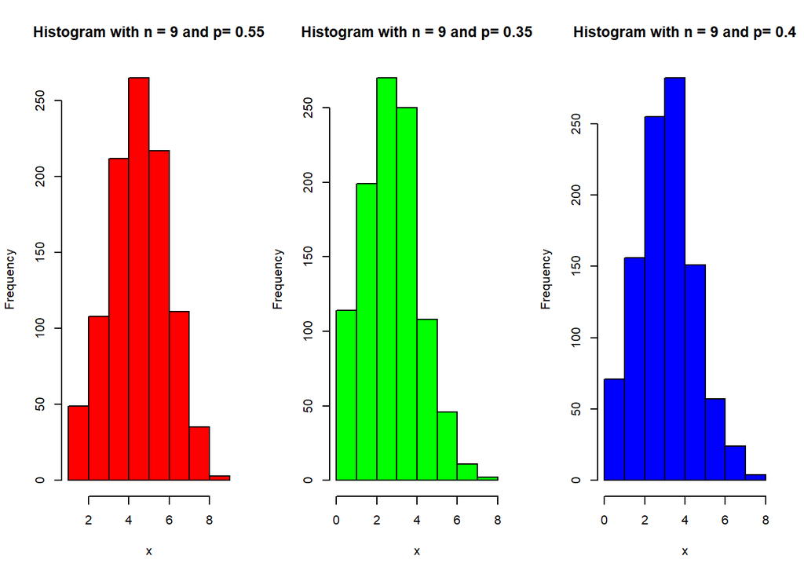

```r
set.seed(11)
par(mfrow=c(1, 3))
n = c(9, 9, 9) # size
p = c(0.55, 0.35, 0.4) # Probability
color = c("red", "green", "blue")
for(i in 1:3) {
 x = rbinom(1000, n[i], p[i])
 hist(x, col=color[i], main = paste("Histogram with n =", n[i], "and p=", p[i]))
}
```

**Poisson Distribution**

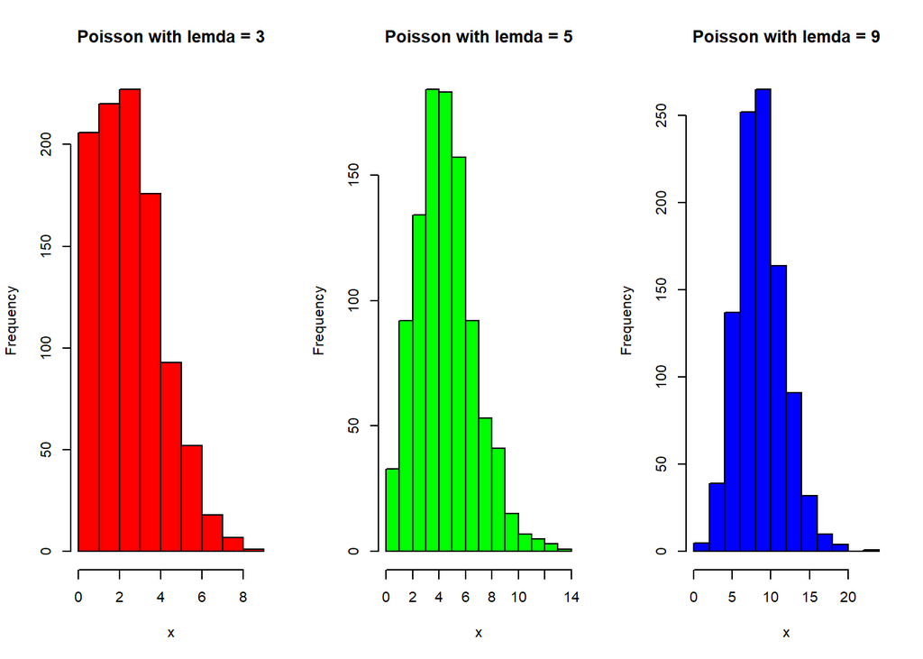

```r
set.seed(12)
par(mfrow=c(1,3))
p <- c(3,5,9)
color <- c("red", "green", "blue")
for(i in 1:3) {
 x = rpois(1000, p[i])
 hist(x, col=color[i], main=paste("Poisson with lemda =", p[i]))
}
```

**Problem: 1 - Suppose X follows a normal distribution with mean $\mu$ and variance $\sigma^2$.**

**(i) Plot the distributions on a graph paper separately with ($\mu = 3, \sigma^2 = 16), (\mu = 5, \sigma^2 = 16)$, and ($\mu = 4, \sigma^2 = 16$) and compare the graphs.**

**(ii) Plot the distributions on same graph paper with ($\mu = 4, \sigma^2 = 4), (\mu = 4, \sigma^2 = 9)$, and ($\mu = 4, \sigma^2 = 16)$**

#### Solution 1 (i):

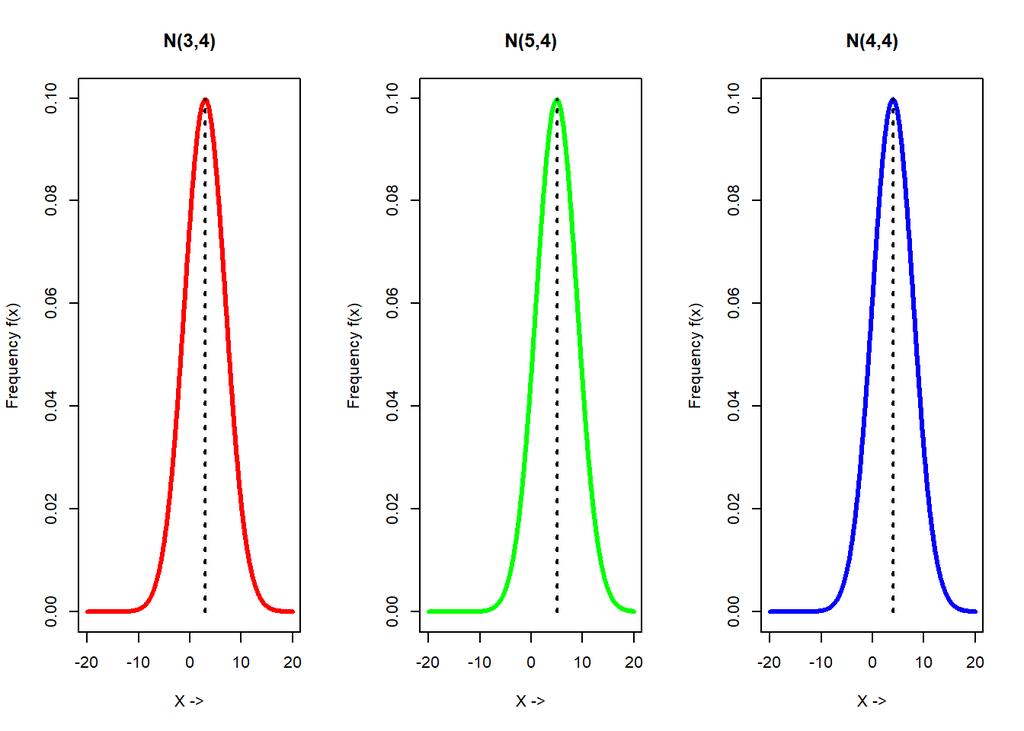

```r
set.seed(21)
par(mfrow=c(1, 3))

mu = c(3, 5, 4)
sigma = c(4, 4, 4)
colors = c("red", "green", "blue")
labels = paste0("N(", mu, ",", sigma, ")")

x = seq(-20, 20, length.out=1000)

for(i in 1:length(mu)) {    # length(mu) = 3
  fx <- dnorm(x, mean= mu[i], sd = sigma[i])
  plot(x, fx, type = "l", main = labels[i], col=colors[i], lwd=3,
       xlab = "X ->", ylab = "Frequency f(x)")

  segments(x0=mu[i], x1=mu[i], y=0, y1 = max(fx), lwd=2, lty=3)
}
```

#### Solution 1 (ii):

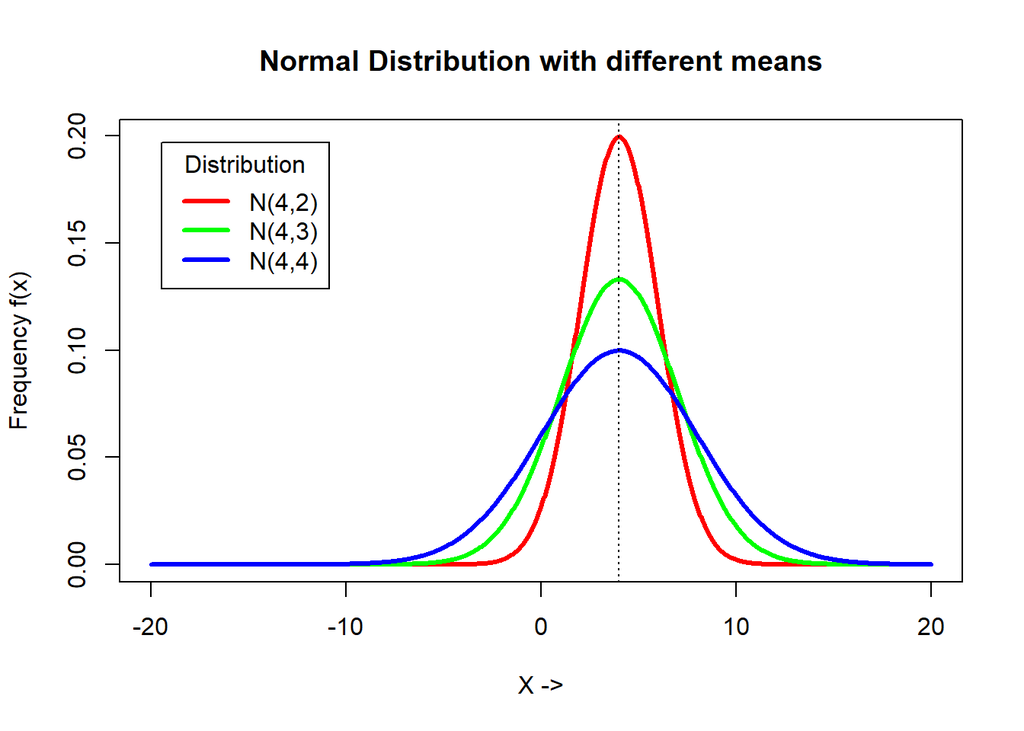

```r
set.seed(21)
par(mfrow=c(1, 1))

mu = c(4, 4, 4)
sigma = c(2, 3, 4)
colors = c("red", "green", "blue")
labels = paste0("N(", mu, ",", sigma, ")")

x = seq(-20, 20, length.out=1000)

for(i in 1:length(mu)) {
  fx <- dnorm(x, mean= mu[i], sd = sigma[i])
  if(i==1) {
    plot(x, fx, type = "l", main = "Normal Distribution with different means", col=colors[i], lwd=3,
       xlab = "X ->", ylab = "Frequency f(x)")
  } else {
    lines(x, fx, col=colors[i], lwd=3)
  }
}
abline(v=mu[1], lty=3)

legend("topleft", inset = 0.05, title = "Distribution", labels, lty = 1, lwd=3, col = colors)
```

**Problem 2: Generate 1200 random samples of size n = 12 with $\mu = 4$ and $\sigma^2 = 9$. Suppose $s^2=\frac{1}{n-1}\sum_i^n (x_i - \bar{x})^2$. Using sitable graph, justify that $\frac{(n-1)s^2}{\sigma^2}$ follows a chi-square distribution with (n-1) degress of freedom.**

### Method: 01

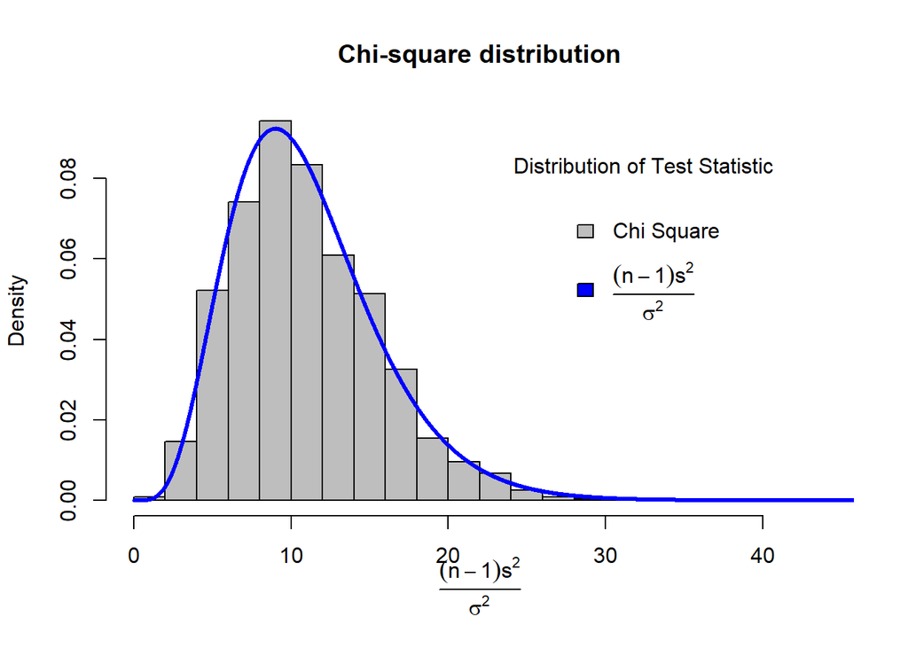

```r
set.seed(11)
n = 12
mu = 4
sigma = 3
it = 1200

xvar = array()
for(i in 1:it) {
  x = rnorm(n, mu, sigma)
  xvar[i] = var(x) # list of variances
}

equation <- expression(frac((n-1)*s^2,sigma^2))

test_statistic = ((n-1)*xvar)/sigma^2
hist(test_statistic, breaks = 15, freq = F, col="gray",  xlab = equation, main="Chi-square distribution")

x2 = seq(0, 120, 0.01)
chisq_pdf = dchisq(x2, df=n-1)
lines(x2, chisq_pdf, col="blue", lwd=3)

legend("topright", inset = 0.1, title = "Distribution of Test Statistic", c("Chi Square", equation), fill = c("gray", "blue"), bty = "n")
```